# R Notebook

Name: Mayuri Patel

Email: mpate131@uncc.edu

title: “Lab5_AdvStats”

1. We will utilize our RNA seq dataset of E. Coli genes from mice. The URL is here: http://afodor.github.io/classes/stats2015/longitdunalRNASeqData.zip. Read and normalize the counts table ( “nc101_scaff_dataCounts.txt “ into R).
- This code is all about unzipping the file:

```r
#set the working directory to the file location
setwd("C:/Users/mpate131/Desktop/AdvStats")

#set the variable of the zip file
zipFile<- "C:/Users/mpate131/Desktop/AdvStats/longitdunalRNASeqData.zip"

outDir<-"C:/Users/mpate131/Desktop/AdvStats" # Define the folder where the zip file should be unzipped to

unzip(zipFile,exdir=outDir)  # unzip the file
```

- Reading the file of datacount from the directory:

```r
#read the table
myTable<-read.table("nc101_scaff_dataCounts.txt",sep="\t",header=TRUE,row.names=1)
head(myTable) #viewing the data using head function
```

|  | D2_01 | D2_02 | D2_03 | W12_01 | W12_02 | W12_03 | w20_01 | w20_02 | w20_03 | w20_04 | w20_05 |
| --- | --- | --- | --- | --- | --- | --- | --- | --- | --- | --- | --- |
| NC101_00003 | 329 | 29 | 40 | 97 | 423 | 141 | 469 | 342 | 884 | 713 | 52 |
| NC101_00004 | 30 | 2 | 6 | 7 | 83 | 34 | 76 | 45 | 131 | 127 | 65 |
| NC101_00005 | 145 | 53 | 23 | 122 | 271 | 128 | 102 | 57 | 134 | 112 | 13 |
| NC101_00006 | 510 | 80 | 54 | 156 | 717 | 193 | 489 | 228 | 536 | 487 | 57 |
| NC101_00007 | 5 | 3 | 0 | 13 | 25 | 1 | 9 | 2 | 30 | 9 | 11 |
| NC101_00008 | 14 | 4 | 2 | 8 | 65 | 14 | 208 | 82 | 302 | 241 | 14 |

- (The first 3 columns are “day 2”, the next 3 columns are “week 12” and the last 5 are “week 18”). Remember, that day 2 is before the mice have inflammation symptoms, week 12 is associated with inflammation and week 18 is associated with cancer.
- Normalize the data:

```r
# remove rare genes
myTable <- myTable[ apply( myTable,1, median)> 5,]

myTNorm <- myTable
#For loop each column
for ( i in 1:ncol(myTable))
{
    colSum = sum(myTable[,i]) # all rows and each column and summing all the column
    myTNorm[,i] =myTNorm[,i]/colSum # normalizing the data and saving it in the empty variable myTNorm.

}
head(myTNorm)
```

|  | D2_01 | D2_02 | D2_03 | W12_01 | W12_02 | W12_03 | w20_01 | w20_02 | w20_03 | w20_04 | w20_05 |
| --- | --- | --- | --- | --- | --- | --- | --- | --- | --- | --- | --- |
| NC101_00003 | 5.680896e-04 | 1.838224e-04 | 5.226435e-04 | 3.748604e-04 | 3.906539e-04 | 3.327968e-04 | 3.955886e-04 | 4.990602e-04 | 5.194085e-04 | 4.562896e-04 | 7.653778e-05 |
| NC101_00004 | 5.180148e-05 | 1.267740e-05 | 7.839653e-05 | 2.705178e-05 | 7.665312e-05 | 8.024887e-05 | 6.410392e-05 | 6.566582e-05 | 7.697117e-05 | 8.127459e-05 | 9.567223e-05 |
| NC101_00005 | 2.503738e-04 | 3.359512e-04 | 3.005200e-04 | 4.714739e-04 | 2.502771e-04 | 3.021134e-04 | 8.603420e-05 | 8.317671e-05 | 7.873387e-05 | 7.167523e-05 | 1.913445e-05 |
| NC101_00006 | 8.806252e-04 | 5.070962e-04 | 7.055688e-04 | 6.028683e-04 | 6.621721e-04 | 4.555303e-04 | 4.124581e-04 | 3.327068e-04 | 3.149355e-04 | 3.116593e-04 | 8.389719e-05 |
| NC101_00007 | 8.633580e-06 | 1.901611e-05 | 0.000000e+00 | 5.023902e-05 | 2.308829e-05 | 2.360261e-06 | 7.591253e-06 | 2.918481e-06 | 1.762698e-05 | 5.759617e-06 | 1.619069e-05 |
| NC101_00008 | 2.417403e-05 | 2.535481e-05 | 2.613218e-05 | 3.091632e-05 | 6.002955e-05 | 3.304365e-05 | 1.754423e-04 | 1.196577e-04 | 1.774450e-04 | 1.542297e-04 | 2.060633e-05 |

2. For every row in the normalized spreadsheet, run three t-tests ( “day 2” vs. “week 12”, “day 2” vs. “week 18” and “week 12” vs. “week 18”. At a p < .05 threshold fill in the following table: # of genes significant at p <0.05 uncorrected # genes significant at p <0.05 BH FDR corrected # genes significant at p <0.05 Bonferroni corrected
- The three t-tests:

```r
#here, mean of day2 , week12, week18 is taken for those columns for each gene
#then do t-test for mean of “day 2” vs. “week 12”, “day 2” vs. “week 18” and “week 12” vs. “week 18”

#t-test
#stored all the p values for each gene into a variable
d2w12_pval <- apply(myTNorm,1,function(x){t.test(x[1:3],x[4:6])$p.value}) #“day 2” vs. “week 12”
d2w18_pval <- apply(myTNorm,1,function(x){t.test(x[1:3],x[7:11])$p.value}) #“day 2” vs. “week 18”
w12w18_pval <- apply(myTNorm,1,function(x){t.test(x[4:6],x[7:11])$p.value})#“week 12” vs. “week 18”
```

- For p <0.05 uncorrected:

```r
#for d2w12:
uncorrected_d2w12 <- sum(d2w12_pval <= 0.05)
print(paste("The uncorrected p-values <0.05 for d2w12 is:",uncorrected_d2w12))
```

```
## [1] "The uncorrected p-values <0.05 for d2w12 is: 398"
```

```r
#for d2w18:
uncorrected_d2w18 <- sum(d2w18_pval <= 0.05)
print(paste("The uncorrected p-values <0.05 for d2w18 is:",uncorrected_d2w18))
```

```
## [1] "The uncorrected p-values <0.05 for d2w18 is: 1243"
```

```r
#for w12w18:
uncorrected_w12w18 <- sum(w12w18_pval <= 0.05)
print(paste("The uncorrected p-values <0.05 for w12w18 is:",uncorrected_w12w18))
```

```
## [1] "The uncorrected p-values <0.05 for w12w18 is: 810"
```

- For p <0.05 BH FDR corrected:

```r
# using the p.adjust function we can find the p values of BH FDR corrected
# taking the method
#for d2w12:
d2w12_BH <- p.adjust(d2w12_pval, method="BH")
d2w12_BHpval <- sum(d2w12_BH<0.05)
print(paste("The p-values <0.05 BH FDR corrected for d2w12 is:", d2w12_BHpval))
```

```
## [1] "The p-values <0.05 BH FDR corrected for d2w12 is: 0"
```

```r
#for d2w18:
d2w18_BH <- p.adjust(d2w18_pval, method="BH")
d2w18_BHpval <- sum(d2w18_BH<0.05)
print(paste("The p-values <0.05 BH FDR corrected for d2w18 is:", d2w18_BHpval))
```

```
## [1] "The p-values <0.05 BH FDR corrected for d2w18 is: 279"
```

```r
#for w12w18:
w12w18_BH <- p.adjust(w12w18_pval, method="BH")
w12w18_BHpval <- sum(w12w18_BH<0.05)
print(paste("The p-values <0.05 BH FDR corrected for w12w18 is:", w12w18_BHpval))
```

```
## [1] "The p-values <0.05 BH FDR corrected for w12w18 is: 15"
```

- For p <0.05 Bonferroni corrected:

```r
# using the p.adjust function we can find the p values of bonferroni corrected
# taking the method
#for d2w12:
d2w12_bon <- p.adjust(d2w12_pval,method="bonferroni")
d2w12_bonpval <- sum(d2w12_bon < 0.05)
print(paste("The p-values <0.05 Bonferroni corrected for d2w12 is:", d2w12_bonpval))
```

```
## [1] "The p-values <0.05 Bonferroni corrected for d2w12 is: 0"
```

```r
#for d2w18:
d2w18_bon <- p.adjust(d2w18_pval, method="bonferroni")
d2w18_bonpval <- sum(d2w18_bon<0.05)
print(paste("The p-values <0.05 Bonferroni corrected for d2w18 is:", d2w18_bonpval))
```

```
## [1] "The p-values <0.05 Bonferroni corrected for d2w18 is: 3"
```

```r
#for w12w18:
w12w18_bon <- p.adjust(w12w18_pval, method="bonferroni")
w12w18_bonpval <- sum(w12w18_bon<0.05)
print(paste("The p-values <0.05 Bonferroni corrected for w12w18 is:", w12w18_bonpval))
```

```
## [1] "The p-values <0.05 Bonferroni corrected for w12w18 is: 1"
```

- Generated a table using data.frame and knitr

```r
#generated the data frame of the table which we have to use
df <- data.frame("sample" = c("day2.Vs.week12","day2.Vs.week18","week12.Vs.week18"),
"No. genes significant at p <0.05 uncorrected" = c(uncorrected_d2w12,uncorrected_d2w18,uncorrected_w12w18),
"No. genes significant at p <0.05 BH FDR " = c(d2w12_BHpval,d2w18_BHpval,w12w18_BHpval),
"No. genes significant at p <0.05 Bonferroni" = c(d2w12_bonpval, d2w18_bonpval, w12w18_bonpval))
knitr::kable(df) #this prints the table of the dataframe
```

| sample | No..genes.significant.at.p..0.05.uncorrected | No..genes.significant.at.p..0.05.BH.FDR. | No..genes.significant.at.p..0.05.Bonferroni |
| --- | --- | --- | --- |
| day2.Vs.week12 | 398 | 0 | 0 |
| day2.Vs.week18 | 1243 | 279 | 3 |
| week12.Vs.week18 | 810 | 15 | 1 |

3. Make histograms of all the uncorrected p-values for each of the three companions. Are any of the distributions uniform?

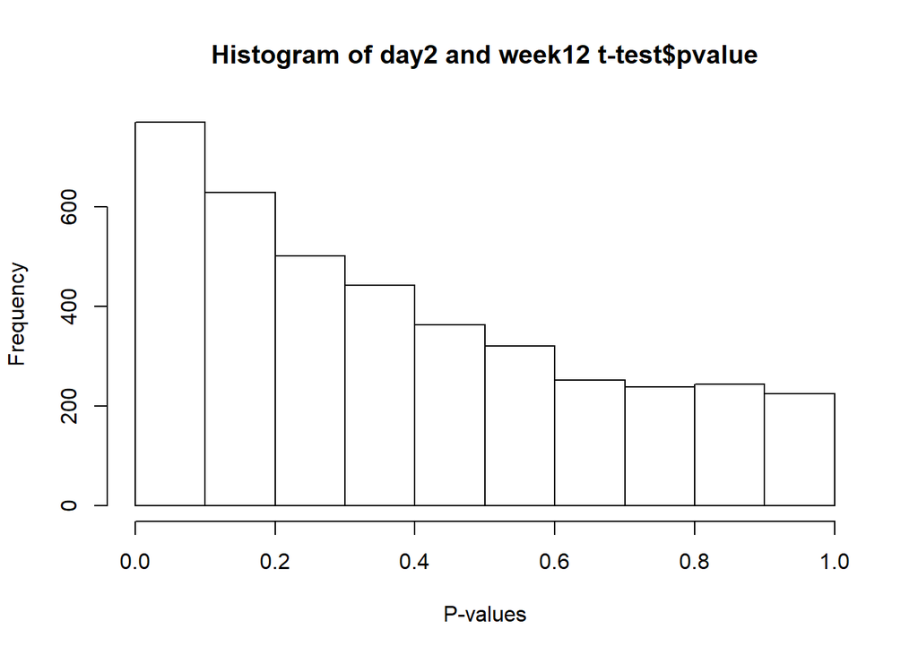

```r
#histogram of d2w12:
hist(d2w12_pval, xlab = "P-values", main="Histogram of day2 and week12 t-test$pvalue")
```

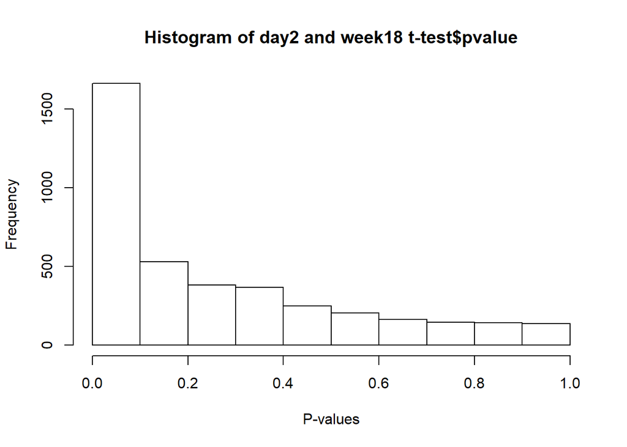

```r
#histogram of d2w18:

hist(d2w18_pval, xlab = "P-values", main="Histogram of day2 and week18 t-test$pvalue")
```

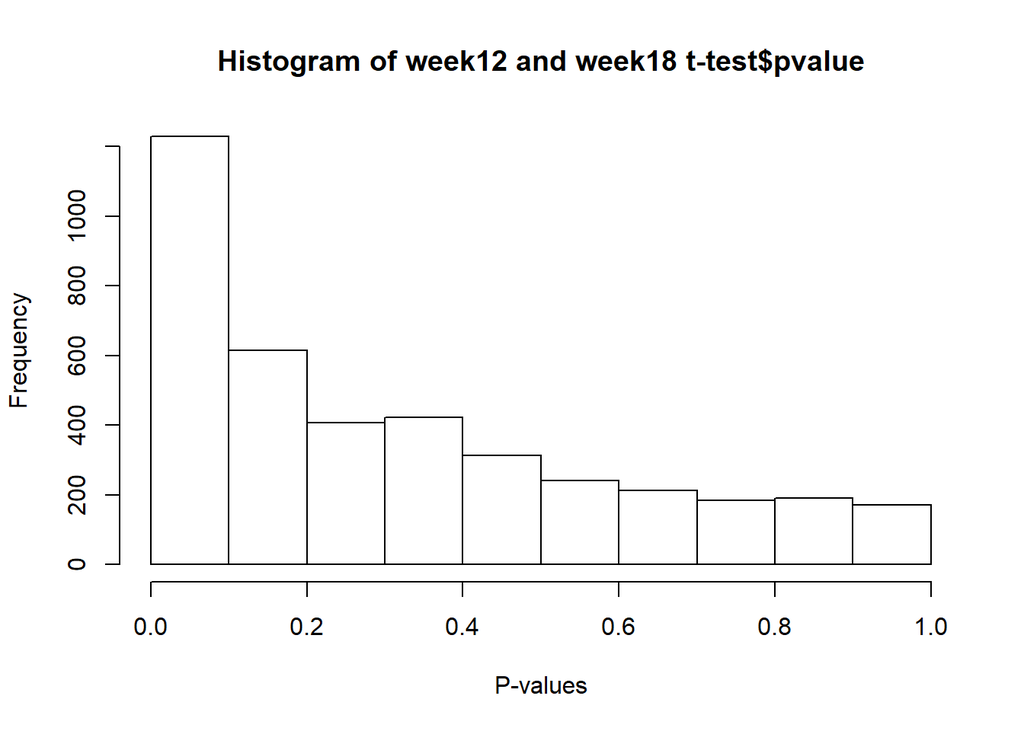

```r
#histogram of w12w18:

hist(w12w18_pval, xlab = "P-values", main="Histogram of week12 and week18 t-test$pvalue")
```

- None of the three companions show the uniform distribution.
4. Based on these data, when is the biggest shift in the transcriptome? Which samples are most different from one another?
- The biggest shift in the transcriptome is seen in day 2 and week 18 pair of condition as it shows the most number of significant changes in genes. The samples most different from one another is also day 2 and week 18 pair as there is significant changes in the genes number over the other two.